# Change in Patient Count Over Time with Respect to Different SIMD

the RegRession Rebels Kenny Chen, Matthew Brown, Jake Leung, Aleksandra Iwaszkiewicz, Sarah De Giuli

2023-12-01

## Introduction

Mental Health issues have been gaining a lot of traction in recent years with communities of people on social media putting in the efforts to spread awareness about the prevalence of mental health issues among individuals of the youngest generations. A number of articles have been published commenting on this observable phenomenon and the surge in numbers of people suffering from mental health problems during covid years, some of them being published by government organizations like the NHS, focusing on the situation in the UK more recently, reporting on mental disorder diagnoses in children and young adults. The general public’s proliferation in interest regarding the the impact these issues have had on the individuals’ daily life, prompt the question of how this trend developed over time, and more importantly, how is it represented in the numbers of patients at institutions that specialize in treating cases of patients that require professional support. As concerning as the issue has been reported to be by these articles, the severity of it can be better judged by the institutions tackling the treatment of these cases and their ability of successfully supporting those in need. Hence, this investigation attempts to look into how successful this has been over the course of the past 25 years.

## Research Question

Answering the research question aims to identify whether there exists a correlation between how numbers of patients and numbers of patients discharged have changed over time. Additionally, the investigation analyzes the SIMD score, the index of deprivation, to determine the existence of a correlation and potential impact of the assigned deprivation index of an area on the mental health of its inhabitants, reflected and discerned on the basis of the discharge numbers and patient counts.

This topic of investigation is worth exploring due to its potential to understanding how the approach to treating mental health has developed over the years, from 1997 to modern day. This could function as a basis for making predictions about the future numbers of patients in mental health institutions, and therefore, form conclusions about the efficiency and success of treating mental health in Scotland. While this may be of interest to the investigation, it is important to remember that a number of assumptions are being made, which will be stated and explained appropriately throughout the process that is being documented. As insightful as the data used for the investigation is, this is a topic of great importance and extent, so it is worth bearing in mind that this exploration should not be treated as a whole and complete analysis, more so a beginning to the conversation that offers initial conclusions prompting further questions and allowing room to delve into the specifics and intricacies of mental health related data analysis.

## Data

To begin with the data was appropriately cleaned and organized. This was done primarily by remaining entries for particular variables. Originally, the NHS data sets use specific codes to denote diagnosis (ICD10), health board of residence regions (HBR), and health board of treatment regions (HBT). Additionally, the quantifier variables were removed. This left Financial Year, icd categories, translated hbr, translated hbt, Discharge Count and Rates, Patients Count and Rates, Hospital Residents Count and Rates, Age Group, Sex, and SIMD, which is the Scottish index of multiple deprivation. These variables were to be of greatest interest in the attempt to answering the research question, but ultimately not all of them are represented through visualizations. Ultimately, it was the numbers of patients and numbers of patients discharged, as well as, the respective rates variables for both, and the SIMD that were explored most intensely.

NHS Scotland 2018 Mental Health Inpatient Activity Electronic Dataset https://www.opendata.nhs.scot/dataset/mental-health-inpatient-activity accessed on Friday 20th October 2023

## Initial Visualizations

To begin, scatter plots for total numbers of patients and total numbers of patients discharged over the last 25 years were created. This is depicted below and the primary premise of these plots was to provide an idea about the trends that have occurred since 1997. Specifically when considering the plots as a pair, to observe and understand how the numbers of patients compare to the discharge numbers.

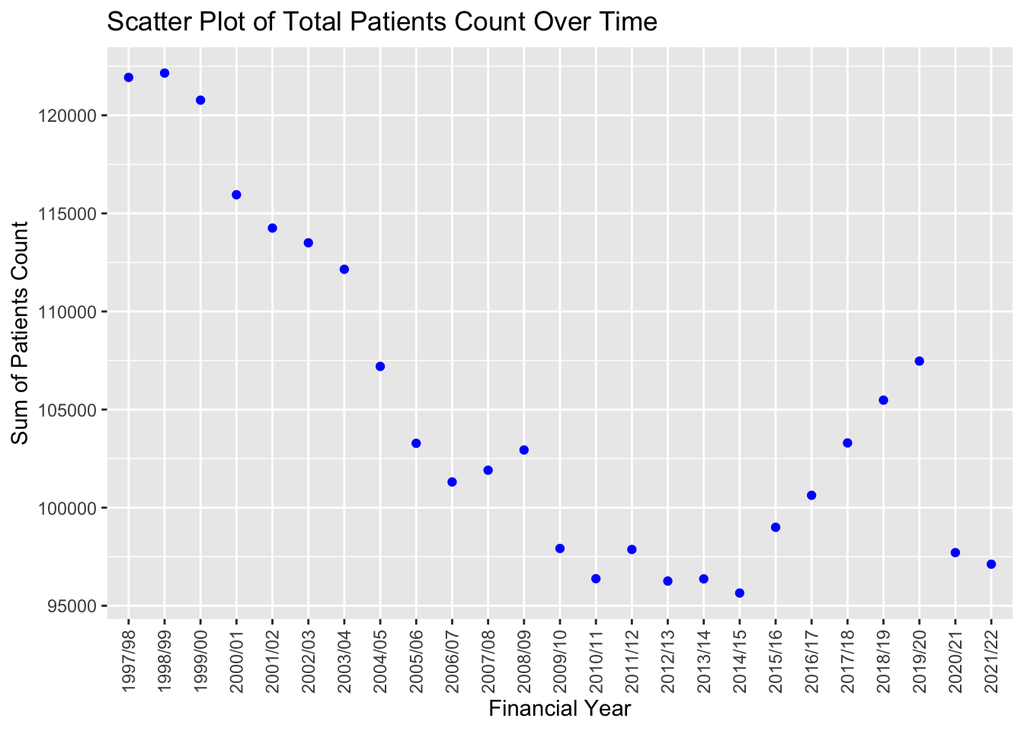

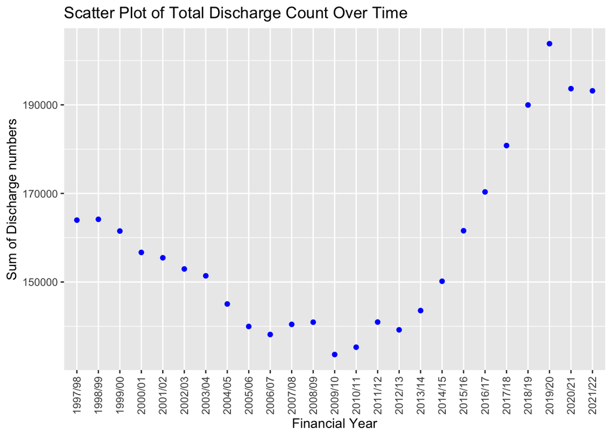

Looking at the plots somewhat opposite tendencies can be observed. The visualization of the sum of patients depicts an initially steep decline, with the highest number achieved in the financial year of 1998/99. The values plummet quite consistently onward, with the exception of the years 2007/08 and 2008/09 that experience a slight increase. It could be deduced that this is an effect of the 2008 financial crisis. A less noticeable deviation from this trend is the value for the year 2010/11, which intrigued the group because of how it appears to mark the end of the period of drastic decline in patient numbers. The minimum value appears slightly beyond, for the year of 2014/15, and the numbers have been increasing since, excluding most recent years. The years 2020 - 2022 experience an aggressive drop in numbers of patients, undoubtedly connected to the pandemic. While the fall in discharge numbers in recent years is evident in the second plot, it is not quite as severe. Also, it appears that from the year 2010/11, in contrast to the previous graph, the numbers of discharged patients have been consistently increasing. Whereas, in the earlier years they achieved lower values, but also followed a decreasing tendency, not unlike that of the first graph. Here the minimum value is associated with the year 2009/10, with 2010/11 not being much higher. The graphs do share the space where lowest values are present. They also present with similar trends, but the vertical axes assuming different scales is misleading for comparing actual values. Nonetheless, the alikeness can be understood as high patient numbers in a given year correspond to high discharge numbers in that year, with the same being true of low values.

Next, the investigation moves towards the analysis of SIMD, the deprivation index and its connection to patient numbers. Before looking at the provided visualization it is important to note that the index is a value between 1 and 5, with 1 being deprived in terms of income, employment, education, health, access to services, crime and housing. With health being one of the factors contributing to the assigned value of the index to a region, it is a natural step to consider how narrowing this to mental health is reflected. This is presented in the histogram below.

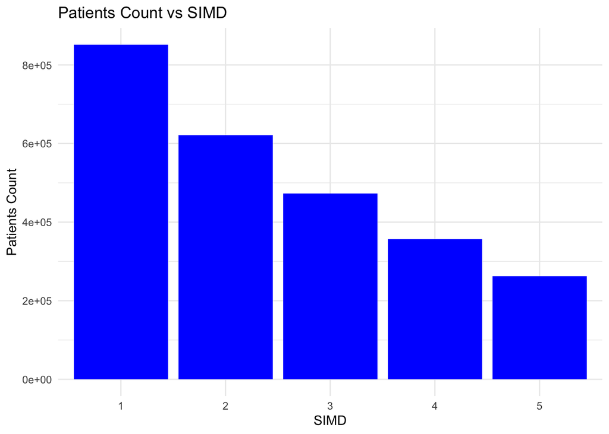

Not entirely unsurprisingly, the histogram clearly proves that areas which are considered more deprived and receive a lower value of the index are the ones that the greatest number of patients belong to. The differences between the numbers of patients diminish as the index values progress, but it did surprise the team that the least deprived areas persisted as those with the least number of patients as clearly as the visualization documents.

This is further shown when this information is plotted as a scatter graph with a regression line fitted to the points. The difference being, that it is the SIMD value against patient rates that are being depicted, which is the annual number of patients relative to the size of the population expressed per 100,000 population.

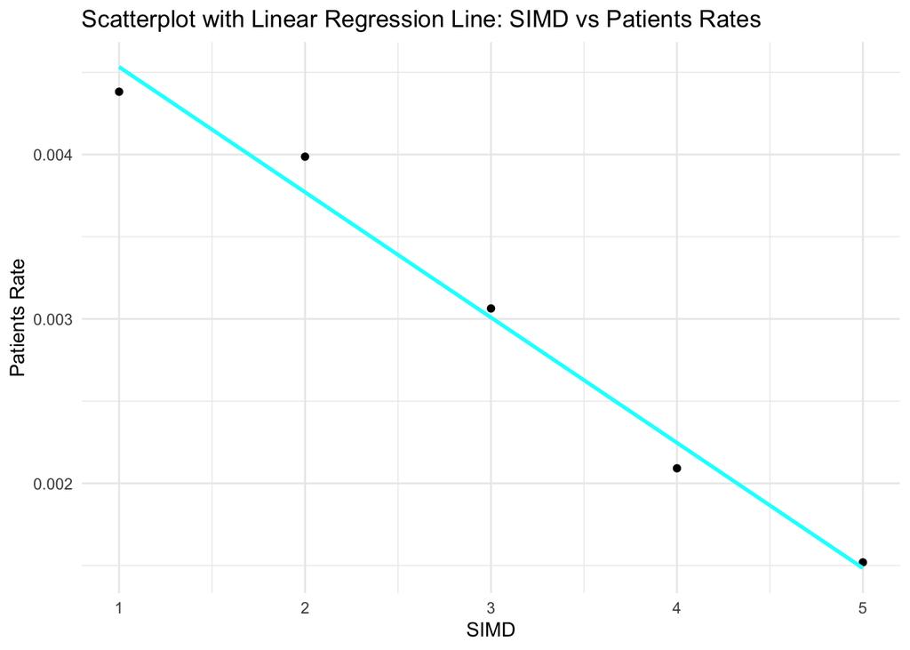

As before, the value of patients rate clearly decreases as the SIMD index increases, meaning that a greater number of patients belongs to areas considered deprived. The gradient of the graph which was found to be -0.000762, so moving to an index one higher yields a decrease in the value of patient rates by -0.000762. This appears as a small value, but it is important to remember that patient rates are expressed per 100,000 of population.

## Linear Model

Having got an idea about what the data can inform us of, it was used to move onto creating a linear model for patients rates against SIMD. The choice to continue using the patient rates variable stems from the fact that patient numbers, as was mentioned when discussing the preliminary visualizations, can be misleading and troublesome when comparing to another variable. Fitting a linear model shows the negative gradient of -0.000762 and the intercept of the vertical axis at 0.00529. This was used to plot an augmented linear model to look at the pattern in residuals.

```
## # A tibble: 2 × 5
##   term         estimate std.error statistic   p.value
##   <chr>           <dbl>     <dbl>     <dbl>     <dbl>
## 1 (Intercept)  0.00529  0.0000620      85.3 0
## 2 SIMD        -0.000762 0.0000187     -40.7 4.46e-318
```

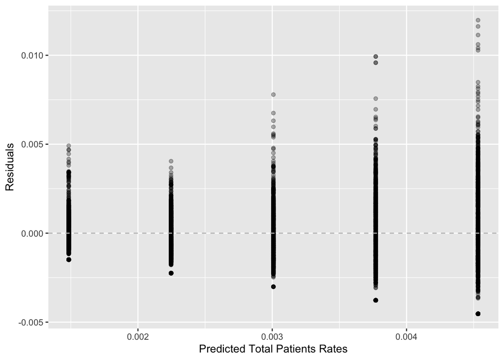

```
## [1] "R-squared: 0.228"
```

```r
diagnosis_pre_2011 <- diagnosis_BUT_READABLE %>%
  mutate(FinancialYear = strtoi (substring(FinancialYear, 1,4))) %>%
  filter(FinancialYear < 2011, FinancialYear < 2020)

  diagnosis_post_2011 <- diagnosis_BUT_READABLE %>%
  mutate(FinancialYear = strtoi (substring(FinancialYear, 1,4))) %>%
  filter(FinancialYear >= 2011 , FinancialYear < 2020)
```

Two linear models were fitted appropriately, and are documented below.

Pre-2011 Linear Model

```
## parsnip model object
##
##
## Call:
## stats::lm(formula = PatientsCount ~ FinancialYear, data = data)
##
## Coefficients:
##   (Intercept)  FinancialYear
##     13735.290         -6.682
```

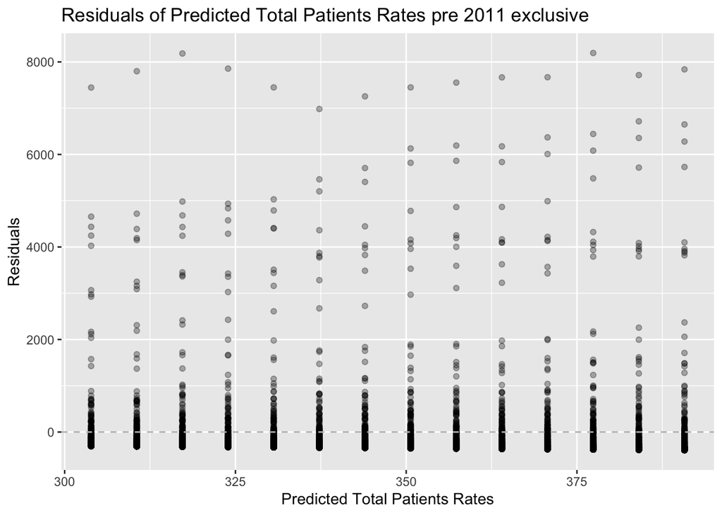

```
## [1] 0.0008965773
```

Post-2011 Linear Model

```
## parsnip model object
##
##
## Call:
## stats::lm(formula = PatientsCount ~ FinancialYear, data = data)
##
## Coefficients:
##   (Intercept)  FinancialYear
##     -8733.332          4.492
```

[figure not shown]

```
## [1] 0.000197397
```

The pre-2011 plot has a negative gradient value indicative of the fact that from 1997 to 2011 the total number of patients fell consistently. Whereas, the graph for years from, and including, 2011 to 2020 has a positive gradient but of lower value. It can be deduced that the trends are opposite but of varying degree. The patient numbers have fallen in the early years at a rate steeper than at which they have been growing since 2011. The R squared values, however, are extremely low for these models deeming them unfit and having poor ability of explaining the variability in the population numbers. This prompts the introduction of some changes to improve this model.

For this model to be able to explain the variability of the data more accurately, a change was made to analyze cumulative data by looking into the total number of patients. The means of introducing this change are documented below.

```r
diagnosis_pre_2011_cum <- diagnosis_pre_2011 %>% group_by(FinancialYear) %>% summarise(TotalPatientsCount = sum(PatientsCount, na.rm = TRUE))

diagnosis_post_2011_cum <- diagnosis_post_2011 %>% group_by(FinancialYear) %>% summarise(TotalPatientsCount = sum(PatientsCount, na.rm = TRUE))
```

Having this as the basis, improved models looking into how the patient numbers changed over time could have been made. The divide into 2 separate models, for the periods 1997-2011 and 2011-2020, persist and the visualizations of the residuals plots are presented.

```
## parsnip model object
##
##
## Call:
## stats::lm(formula = TotalPatientsCount ~ FinancialYear, data = data)
##
## Coefficients:
##   (Intercept)  FinancialYear
##       4326616          -2105
```

[figure not shown]

```
## [1] 0.963175
```

[figure not shown]

```
## [1] 0.810157
```

Our research has also shown that from 1997 to 2011 the total number of patients fell consistently. They then remain about the same until 2015. Since then they have started to increase except for a massive sudden drop in 2020. The drop in 2020 is likely an anomaly caused by the covid-19 pandemic and we would predict that patient numbers would continue to increase over the next years unless action is taken to prevent it.

## References

https://www.forbes.com/health/mind/mental-health-statistics/#:~:text=Worldwide%3A%20Due%20to%20the%20COVID,is%20about%20a%2025%25%20increase.

https://www.england.nhs.uk/2023/11/one-in-five-children-and-young-people-had-a-probable-mental-disorder-in-2023/

https://www.opendata.nhs.scot/dataset/mental-health-inpatient-activity accessed on Friday 20th October 2023

https://www.gov.scot/collections/scottish-index-of-multiple-deprivation-2020/